# TP 1 - Franco Piergallini Guida

```r
library(tidyverse)
library(lubridate)
library(GGally)
library(tidyverse)

library(corrplot)
library(ggplot2)
library(ggthemes)

library(tidymodels)
library(rsample)

library(caret)
library(robustbase)
library(broom)
```

```r
EMSE_df = read.csv('encuesta_salud_train.csv')
```

# ¿Qué puede mencionar sobre su estructura y variables?

```r
glimpse(EMSE_df)
```

```
Rows: 7,024
Columns: 16
$ record                        <int> 502, 26488, 31473, 14154, 36578, 53730, 11892, 35549, 14928, 11754, 40850, 11038, 32832, 31300, 32497, 6961, 3…
$ edad                          <int> 17, 15, 15, 16, 17, 15, 13, 17, 17, 16, 16, 14, 15, 17, 15, 14, 15, 17, 17, 16, 14, 12, 15, 17, 15, 16, 16, 16…
$ genero                        <chr> "Femenino", "Masculino", "Masculino", "Masculino", "Masculino", "Masculino", "Femenino", "Femenino", "Masculin…
$ nivel_educativo               <chr> "2do año/11vo grado nivel Polimodal o 4to año nivel Secundario", "1er año/10mo grado nivel Polimodal o 3er año…
$ altura                        <int> 165, 178, 172, 170, 170, 178, 156, 163, 164, 167, 185, 146, 180, 175, 183, 165, 165, 157, 165, 170, 174, 163, …
$ peso                          <int> 62, 62, 62, 65, 75, 88, 46, 60, 57, 51, 100, 33, 62, 70, 80, 60, 47, 50, 50, 70, 75, 55, 64, 59, 86, 51, 71, 4…
$ frecuencia_hambre_mensual     <chr> "Rara vez", "Rara vez", "Nunca", "Nunca", "Rara vez", "Nunca", "Nunca", "Nunca", "Nunca", "Nunca", "Nunca", "R…
$ dias_consumo_comida_rapida    <int> 0, 0, 3, 1, 1, 2, 0, 0, 0, 3, 4, 2, 1, 1, 3, 0, 0, 0, 0, 1, 0, 6, 0, 1, 0, 2, 0, 2, 0, 0, 5, 1, 0, 0, 1, 1, 0,…
$ edad_consumo_alcohol          <chr> "14 o 15 años", "7 años o menos", "Nunca tomé alcohol más que unos pocos sorbos", "14 o 15 años", "16 o 17 año…
$ consumo_diario_alcohol        <dbl> 5.0, 4.0, 0.0, 0.0, 0.0, 5.0, 1.0, 0.5, 5.0, 0.0, 5.0, 0.0, 0.0, 2.0, 1.0, 0.0, 5.0, 0.0, 1.0, 1.0, 0.5, 0.0, …
$ dias_actividad_fisica_semanal <int> 7, 7, 7, 7, 0, 7, 0, 2, 7, 3, 2, 2, 7, 1, 4, 0, 1, 6, 5, 7, 3, 0, 7, 5, 2, 2, 4, 2, 7, 4, 7, 0, 6, 4, 0, 3, 2,…
$ consumo_semanal_frutas        <chr> "No comí frutas durante los últimos 7 días", "No comí frutas durante los últimos 7 días", "No comí frutas dura…
$ consumo_semanal_verdura       <chr> "4 a 6 veces durante los últimos 7 días", "4 a 6 veces durante los últimos 7 días", "1 vez al día", "4 o más v…
$ consumo_semanal_gaseosas      <chr> "1 a 3 veces durante los últimos 7 días", "1 a 3 veces durante los últimos 7 días", "4 a 6 veces durante los ú…
$ consumo_semanal_snacks        <chr> "1 a 3 veces durante los últimos 7 días", "No comí comida salada o snacks en los últimos 7 días", "4 a 6 veces…
$ consumo_semanal_comida_grasa  <chr> "No comí comida alta en grasa en los últimos 7 días", "4 a 6 veces durante los últimos 7 días", "No comí comid…
```

El set de datos contiene 7024 observaciones, cada una de ellas tiene 16 características o variables. 9 variables de texto del tipo chr 7 variables numéricas del tipo int y dbl.

```r
table(EMSE_df$consumo_semanal_frutas)
```

```
   1 a 3 veces durante los últimos 7 días                              1 vez al día                            2 veces al día
                                     2286                                       973                                       759
                           3 veces al día    4 a 6 veces durante los últimos 7 días                      4 o más veces al día
                                      336                                       942                                       388
                             Dato perdido No comí frutas durante los últimos 7 días
                                       20                                      1320
```

```r
EMSE_df[rowSums(EMSE_df == 'Dato perdido') != 0, , drop = FALSE]
```

|  | record | edad | genero | nivel_educativo | altura | peso | frecuencia_hambre_mensual | dias_consumo_comida_rapida | edad_consumo_alcohol | consumo_diario_alcohol | dias_actividad_fisica_semanal | consumo_semanal_frutas | consumo_semanal_verdura | consumo_semanal_gaseosas | consumo_semanal_snacks | consumo_semanal_comida_grasa |
| --- | --- | --- | --- | --- | --- | --- | --- | --- | --- | --- | --- | --- | --- | --- | --- | --- |
| 17 | 39376 | 15 | Femenino | 2do año/11vo grado nivel Polimodal o 4to año nivel Secundario | 165 | 47 | Nunca | 0 | 7 años o menos | 5.0 | 1 | No comí frutas durante los últimos 7 días | 1 a 3 veces durante los últimos 7 días | No tomé gaseosas en los últimos 7 días | Dato perdido | 4 a 6 veces durante los últimos 7 días |
| 64 | 12863 | 14 | Femenino | 9no grado nivel Primario/Polimodal o 2do año nivel Secundario | 155 | 45 | Rara vez | 3 | 7 años o menos | 5.0 | 3 | 1 vez al día | No comí verduras ni hortalizas durante los últimos 7 días | 3 veces al día | Dato perdido | 4 a 6 veces durante los últimos 7 días |
| 76 | 26325 | 15 | Masculino | Dato perdido | 167 | 50 | Nunca | 0 | Nunca tomé alcohol más que unos pocos sorbos | 0.0 | 1 | 1 a 3 veces durante los últimos 7 días | 4 a 6 veces durante los últimos 7 días | 1 a 3 veces durante los últimos 7 días | 1 a 3 veces durante los últimos 7 días | 1 a 3 veces durante los últimos 7 días |
| 100 | 25517 | 14 | Masculino | Dato perdido | 160 | 56 | Nunca | 0 | 14 o 15 años | 0.5 | 2 | 3 veces al día | 4 o más veces al día | 1 a 3 veces durante los últimos 7 días | 4 o más veces al día | 1 a 3 veces durante los últimos 7 días |
| 105 | 27870 | 16 | Masculino | 2do año/11vo grado nivel Polimodal o 4to año nivel Secundario | 165 | 58 | Rara vez | 0 | 16 o 17 años | 0.5 | 7 | No comí frutas durante los últimos 7 días | Dato perdido | 4 a 6 veces durante los últimos 7 días | No comí comida salada o snacks en los últimos 7 días | No comí comida alta en grasa en los últimos 7 días |
| 117 | 50744 | 15 | Femenino | 1er año/10mo grado nivel Polimodal o 3er año nivel Secundario | 171 | 75 | Dato perdido | 2 | 12 o 13 años | 0.5 | 0 | 4 a 6 veces durante los últimos 7 días | Dato perdido | 1 vez al día | No comí comida salada o snacks en los últimos 7 días | 1 a 3 veces durante los últimos 7 días |
| 155 | 22533 | 13 | Femenino | 1er año/10mo grado nivel Polimodal o 3er año nivel Secundario | 165 | 57 | Nunca | 0 | 12 o 13 años | 0.0 | 5 | Dato perdido | Dato perdido | 1 a 3 veces durante los últimos 7 días | 4 a 6 veces durante los últimos 7 días | 1 a 3 veces durante los últimos 7 días |
| 163 | 37685 | 13 | Femenino | 8vo grado nivel Primario/Polimodal o 1er año nivel Secundario | 157 | 52 | Nunca | 0 | Nunca tomé alcohol más que unos pocos sorbos | 0.0 | 0 | 4 a 6 veces durante los últimos 7 días | Dato perdido | 4 o más veces al día | 1 vez al día | No comí comida alta en grasa en los últimos 7 días |
| 171 | 41079 | 13 | Masculino | Dato perdido | 165 | 52 | Nunca | 6 | 10 o 11 años | 0.0 | 2 | 2 veces al día | 1 vez al día | 1 a 3 veces durante los últimos 7 días | No comí comida salada o snacks en los últimos 7 días | No comí comida alta en grasa en los últimos 7 días |
| 211 | 9577 | 15 | Femenino | Dato perdido | 171 | 76 | Nunca | 0 | 14 o 15 años | 1.0 | 5 | 1 a 3 veces durante los últimos 7 días | 4 a 6 veces durante los últimos 7 días | 1 a 3 veces durante los últimos 7 días | No comí comida salada o snacks en los últimos 7 días | 4 a 6 veces durante los últimos 7 días |

[output cut: 259 more lines]

```r
nrow(EMSE_df[rowSums(EMSE_df == 'Dato perdido') != 0, , drop = FALSE])/nrow(EMSE_df)*100
```

```
[1] 3.829727
```

Casi 4% de las entradas del set de datos contienen por lo menos 1 dato perdido.

## ¿Cómo es la correlación entre las variables numéricas?

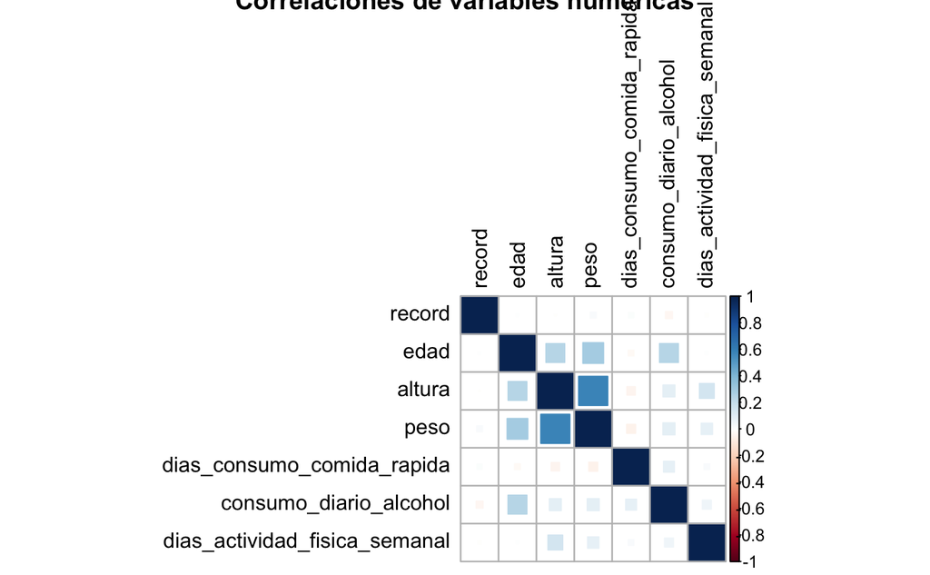

```r
corrplot(cor(select_if(EMSE_df, is.numeric), method='spearman'),
         method = "square",
         type = "full",
         diag = TRUE,
         tl.col = "black",
         bg = "white",
         title = "Correlaciones de variables numericas",
         col = NULL)
```

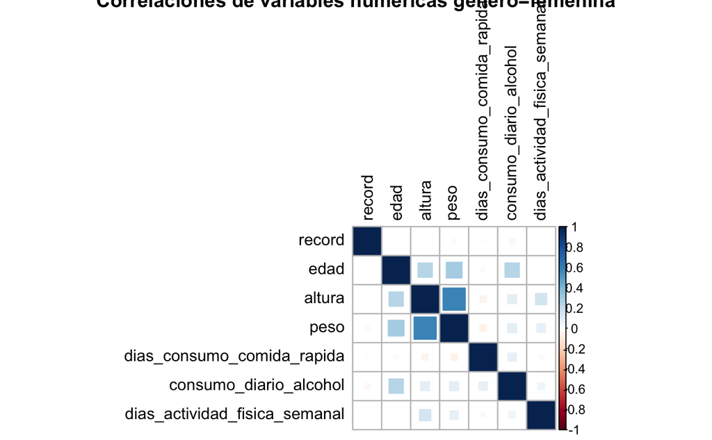

```r
EMSE_femenino = EMSE_df %>%
  filter(genero == "Femenino")
  corrplot(cor(select_if(EMSE_df, is.numeric), method = "spearman"),
           method = "square",
           type = "full",
           diag = TRUE,
           tl.col = "black",
           bg = "white",
           title = "Correlaciones de variables numericas genero=femenina",
           col = NULL)
```

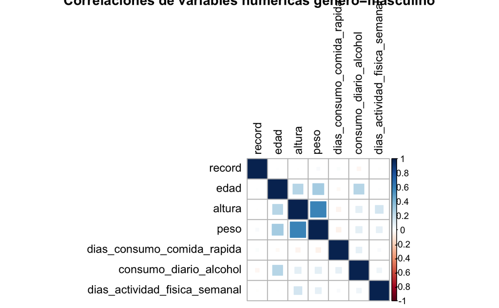

```r
EMSE_masculino = EMSE_df %>%
  filter(genero == "Masculino")
corrplot(cor(select_if(EMSE_df, is.numeric), method='spearman'),
         method = "square",
         type = "full",
         diag = TRUE,
         tl.col = "black",
         bg = "white",
         title = "Correlaciones de variables numericas genero=masculino",
         col = NULL)
```

## Para las categorías de la variable frecuencia de hambre mensual, analice gráficamente la distribución en términos de frecuencia relativa de:

## a) El consumo semanal de verdura.

## b) El consumo semanal de comida grasa.

## ¿Cuáles son las principales características que observa en estos gráficos?

```r
table(EMSE_df$frecuencia_hambre_mensual)
```

```
Algunas veces  Casi siempre  Dato perdido         Nunca      Rara vez       Siempre
          589            78            39          4844          1447            27
```

```r
table(EMSE_df$consumo_semanal_verdura)
```

```
                   1 a 3 veces durante los últimos 7 días                                              1 vez al día
                                                     1929                                                      1227
                                           2 veces al día                                            3 veces al día
                                                      993                                                       264
                   4 a 6 veces durante los últimos 7 días                                      4 o más veces al día
                                                     1510                                                       448
                                             Dato perdido No comí verduras ni hortalizas durante los últimos 7 días
                                                       43                                                       610
```

```r
table(EMSE_df$consumo_semanal_comida_grasa)
```

```
            1 a 3 veces durante los últimos 7 días                                       1 vez al día
                                              3215                                                643
                                    2 veces al día                                     3 veces al día
                                               267                                                104
            4 a 6 veces durante los últimos 7 días                               4 o más veces al día
                                              1079                                                142
                                      Dato perdido No comí comida alta en grasa en los últimos 7 días
                                                51                                               1523
```

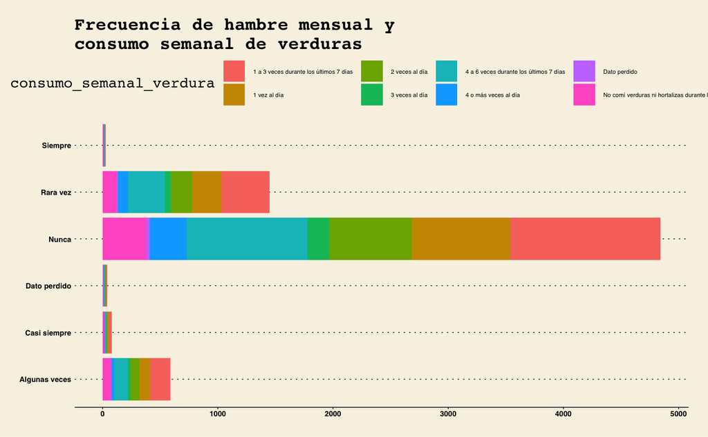

```r
EMSE_df %>%
  select(frecuencia_hambre_mensual, consumo_semanal_verdura) %>%
  table() %>%
  as.data.frame() %>%
  ggplot(., aes(y=frecuencia_hambre_mensual, fill=consumo_semanal_verdura,
                      x=Freq)
         ) +
  ggtitle("Frecuencia de hambre mensual y \nconsumo semanal de verduras") +
  geom_bar(position='stack', stat='identity') +
  theme_wsj(base_size = 5.5)
```

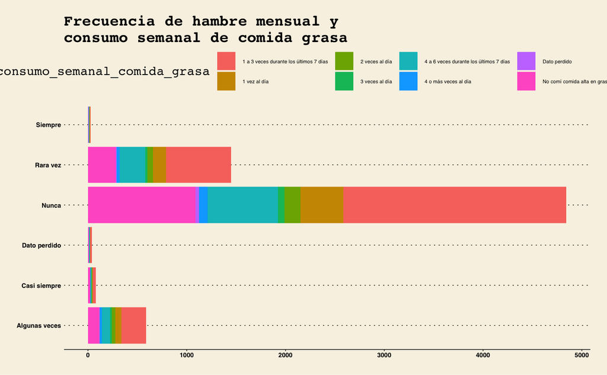

```r
EMSE_df %>%
  select(frecuencia_hambre_mensual, consumo_semanal_comida_grasa) %>%
  table() %>%
  as.data.frame() %>%
  ggplot(., aes(y=frecuencia_hambre_mensual, fill=consumo_semanal_comida_grasa,
                      x=Freq),
         ) +
  ggtitle("Frecuencia de hambre mensual y \nconsumo semanal de comida grasa") +
  geom_bar(position='stack', stat='identity') +
  theme_wsj(base_size = 5.5)
```

Se puede observar, claramente, que el consumo de comida grasa es muy bajo, ya que la gran mayoría o no consumió comida grasa en los ultimos 7 días o lo hizo de 1 a 3 veces.

# Modelo inicial

```r
glimpse(EMSE_df)
```

```
Rows: 7,024
Columns: 16
$ record                        <int> 502, 26488, 31473, 14154, 36578, 53730, 11892, 35549, 14928, 11754, 40850, 11038, 32832, 31300, 32497, 6961, 3…
$ edad                          <int> 17, 15, 15, 16, 17, 15, 13, 17, 17, 16, 16, 14, 15, 17, 15, 14, 15, 17, 17, 16, 14, 12, 15, 17, 15, 16, 16, 16…
$ genero                        <chr> "Femenino", "Masculino", "Masculino", "Masculino", "Masculino", "Masculino", "Femenino", "Femenino", "Masculin…
$ nivel_educativo               <chr> "2do año/11vo grado nivel Polimodal o 4to año nivel Secundario", "1er año/10mo grado nivel Polimodal o 3er año…
$ altura                        <int> 165, 178, 172, 170, 170, 178, 156, 163, 164, 167, 185, 146, 180, 175, 183, 165, 165, 157, 165, 170, 174, 163, …
$ peso                          <int> 62, 62, 62, 65, 75, 88, 46, 60, 57, 51, 100, 33, 62, 70, 80, 60, 47, 50, 50, 70, 75, 55, 64, 59, 86, 51, 71, 4…
$ frecuencia_hambre_mensual     <chr> "Rara vez", "Rara vez", "Nunca", "Nunca", "Rara vez", "Nunca", "Nunca", "Nunca", "Nunca", "Nunca", "Nunca", "R…
$ dias_consumo_comida_rapida    <int> 0, 0, 3, 1, 1, 2, 0, 0, 0, 3, 4, 2, 1, 1, 3, 0, 0, 0, 0, 1, 0, 6, 0, 1, 0, 2, 0, 2, 0, 0, 5, 1, 0, 0, 1, 1, 0,…
$ edad_consumo_alcohol          <chr> "14 o 15 años", "7 años o menos", "Nunca tomé alcohol más que unos pocos sorbos", "14 o 15 años", "16 o 17 año…
$ consumo_diario_alcohol        <dbl> 5.0, 4.0, 0.0, 0.0, 0.0, 5.0, 1.0, 0.5, 5.0, 0.0, 5.0, 0.0, 0.0, 2.0, 1.0, 0.0, 5.0, 0.0, 1.0, 1.0, 0.5, 0.0, …
$ dias_actividad_fisica_semanal <int> 7, 7, 7, 7, 0, 7, 0, 2, 7, 3, 2, 2, 7, 1, 4, 0, 1, 6, 5, 7, 3, 0, 7, 5, 2, 2, 4, 2, 7, 4, 7, 0, 6, 4, 0, 3, 2,…
$ consumo_semanal_frutas        <chr> "No comí frutas durante los últimos 7 días", "No comí frutas durante los últimos 7 días", "No comí frutas dura…
$ consumo_semanal_verdura       <chr> "4 a 6 veces durante los últimos 7 días", "4 a 6 veces durante los últimos 7 días", "1 vez al día", "4 o más v…
$ consumo_semanal_gaseosas      <chr> "1 a 3 veces durante los últimos 7 días", "1 a 3 veces durante los últimos 7 días", "4 a 6 veces durante los ú…
$ consumo_semanal_snacks        <chr> "1 a 3 veces durante los últimos 7 días", "No comí comida salada o snacks en los últimos 7 días", "4 a 6 veces…
$ consumo_semanal_comida_grasa  <chr> "No comí comida alta en grasa en los últimos 7 días", "4 a 6 veces durante los últimos 7 días", "No comí comid…
```

## Se plantea que una primera alternativa para modelar el peso es:

## E(peso) = β0+β1altura+β2edad+β3genero+β4diasActividadF isicaSemanal+β5consumoDiarioAlcohol

## ¿Cuál es la interpretación de cada uno de los coeficientes estimados?

```r
modelo_peso = lm(formula=peso ~ altura + edad + genero + dias_actividad_fisica_semanal + consumo_diario_alcohol,
                 data = EMSE_df)

tidy_modelo_peso = tidy(modelo_peso, conf.int=TRUE)

tidy_modelo_peso
```

| term | estimate | std.error | statistic | p.value | conf.low | conf.high |
| --- | --- | --- | --- | --- | --- | --- |
| (Intercept) | -68.922688070 | 2.33805445 | -29.4786497 | 3.614866e-180 | -73.5059810 | -64.33939510 |
| altura | 0.650606544 | 0.01437975 | 45.2446353 | 0.000000e+00 | 0.6224179 | 0.67879520 |
| edad | 1.406727060 | 0.09385081 | 14.9889709 | 5.121599e-50 | 1.2227511 | 1.59070300 |
| generoMasculino | 1.262643558 | 0.27282821 | 4.6279802 | 3.758831e-06 | 0.7278179 | 1.79746926 |
| dias_actividad_fisica_semanal | -0.087391031 | 0.04992917 | -1.7503000 | 8.011025e-02 | -0.1852673 | 0.01048523 |
| consumo_diario_alcohol | 0.007271379 | 0.06138558 | 0.1184542 | 9.057112e-01 | -0.1130629 | 0.12760566 |

El valor $\hat{\beta_{0}}$ = -68.92 es el peso esperado para cuando todos los otros valores sean 0. Esto no tiene interpretación: una persona no puede tener altura 0, por ejemplo.

Por otro lado, $\hat{\beta_{1}}$ = 0.65, nos indica que por cada unidad de altura el peso aumenta 0.65 unidades de peso. Lo mismo para la edad $\hat{\beta_{2}}$ = 1.40 indicando que por cada unidad de la variable edad el peso aumenta 1.40 unidades de peso.

## ¿Son significativos?

```r
options("scipen"=1)
tidy_modelo_peso %>%
  select(term, statistic, p.value, conf.low, conf.high)
```

| term | statistic | p.value | conf.low | conf.high |
| --- | --- | --- | --- | --- |
| (Intercept) | -29.4786497 | 3.614866e-180 | -73.5059810 | -64.33939510 |
| altura | 45.2446353 | 0.000000e+00 | 0.6224179 | 0.67879520 |
| edad | 14.9889709 | 5.121599e-50 | 1.2227511 | 1.59070300 |
| generoMasculino | 4.6279802 | 3.758831e-06 | 0.7278179 | 1.79746926 |
| dias_actividad_fisica_semanal | -1.7503000 | 8.011025e-02 | -0.1852673 | 0.01048523 |
| consumo_diario_alcohol | 0.1184542 | 9.057112e-01 | -0.1130629 | 0.12760566 |

```r
summary(modelo_peso)
```

```
Call:
lm(formula = peso ~ altura + edad + genero + dias_actividad_fisica_semanal +
    consumo_diario_alcohol, data = EMSE_df)

Residuals:
    Min      1Q  Median      3Q     Max
-28.014  -6.527  -1.104   5.050  76.143

Coefficients:
                                Estimate Std. Error t value Pr(>|t|)
(Intercept)                   -68.922688   2.338054 -29.479  < 2e-16 ***
altura                          0.650607   0.014380  45.245  < 2e-16 ***
edad                            1.406727   0.093851  14.989  < 2e-16 ***
generoMasculino                 1.262644   0.272828   4.628 3.76e-06 ***
dias_actividad_fisica_semanal  -0.087391   0.049929  -1.750   0.0801 .
consumo_diario_alcohol          0.007271   0.061386   0.118   0.9057
---
Signif. codes:  0 ‘***’ 0.001 ‘**’ 0.01 ‘*’ 0.05 ‘.’ 0.1 ‘ ’ 1

Residual standard error: 9.914 on 7018 degrees of freedom
Multiple R-squared:  0.3544,    Adjusted R-squared:  0.3539
F-statistic: 770.4 on 5 and 7018 DF,  p-value: < 2.2e-16
```

## ¿El modelo resulta significativo para explicar el peso?

## ¿Qué porcentaje de la variabilidad explica el modelo?

El modelo resulta significativo para explicar el peso en función de las variables ya que obtenemos un p-value < 0.05 en el test de significatividad global. La variabilidad explicada por el modelo es relativamente baja, mirando el $R^{2}$ apreciamos que es sólo del 35%.

# Modelo categóricas

## Se sugiere probar un modelo que incopore el consumo semanal de snacks y una interacción entre el género y la edad, en lugar de actividad física y consumo de alcohol:

## E(peso) = β0 + β1altura + β2edad + β3genero + β4consumoSemanalSnacks + β5genero · edad

## Además se pide explícitamente que la categoría “No comí comida salada o snacks en los últimos 7 días” de la variable consumoSemanalSnacks se encuentre como nivel/categoría basal.

## ¿Cuál es la interpretación de los coeficientes estimados para las categorías de consumoSemanalSnacks y genero . edad? ¿Son significativas?

```r
EMSE_df[EMSE_df$consumo_semanal_snacks == "No comí comida salada o snacks en los últimos 7 días", "consumo_semanal_snacks"] = "basal"

modelo_peso_2 = lm(formula=peso ~ altura + edad + genero + consumo_semanal_snacks + genero*edad,
                   data = EMSE_df)

tidy_modelo_peso_2 = tidy(modelo_peso_2, conf.int=TRUE)

tidy_modelo_peso_2
```

| term | estimate | std.error | statistic | p.value | conf.low | conf.high |
| --- | --- | --- | --- | --- | --- | --- |
| (Intercept) | -65.55103266 | 2.82026758 | -23.24284162 | 3.475876e-115 | -71.07960984 | -60.02245547 |
| altura | 0.64292233 | 0.01452916 | 44.25046943 | 0.000000e+00 | 0.61444077 | 0.67140388 |
| edad | 1.22309343 | 0.12102373 | 10.10622849 | 7.547065e-24 | 0.98585034 | 1.46033653 |
| generoMasculino | -4.61150428 | 2.67876742 | -1.72150230 | 8.520382e-02 | -9.86269837 | 0.63968980 |
| consumo_semanal_snacks1 vez al día | 0.74375676 | 0.44018195 | 1.68965754 | 9.113794e-02 | -0.11913296 | 1.60664648 |
| consumo_semanal_snacks2 veces al día | 0.25697202 | 0.67411352 | 0.38119992 | 7.030665e-01 | -1.06449430 | 1.57843834 |
| consumo_semanal_snacks3 veces al día | 0.07567056 | 1.00456120 | 0.07532698 | 9.399567e-01 | -1.89357313 | 2.04491425 |
| consumo_semanal_snacks4 a 6 veces durante los últimos 7 días | -0.91840382 | 0.43397571 | -2.11625628 | 3.435816e-02 | -1.76912742 | -0.06768021 |
| consumo_semanal_snacks4 o más veces al día | -1.21534110 | 0.87293568 | -1.39224588 | 1.638921e-01 | -2.92655896 | 0.49587677 |
| consumo_semanal_snacksbasal | 1.35163236 | 0.27644506 | 4.88933439 | 1.034285e-06 | 0.80971645 | 1.89354827 |

[output cut: 2 more lines]

Las unicas categorias que son estadisticamente significativas son: basal y 4 a 6 veces durante los últimos 7 días.

## ¿Qué porcentaje de la variabilidad explica el modelo?

```r
summary(modelo_peso_2)
```

```
Call:
lm(formula = peso ~ altura + edad + genero + consumo_semanal_snacks +
    genero * edad, data = EMSE_df)

Residuals:
    Min      1Q  Median      3Q     Max
-29.005  -6.452  -1.157   5.052  75.767

Coefficients:
                                                              Estimate Std. Error t value Pr(>|t|)
(Intercept)                                                  -65.55103    2.82027 -23.243  < 2e-16 ***
altura                                                         0.64292    0.01453  44.250  < 2e-16 ***
edad                                                           1.22309    0.12102  10.106  < 2e-16 ***
generoMasculino                                               -4.61150    2.67877  -1.722   0.0852 .
consumo_semanal_snacks1 vez al día                             0.74376    0.44018   1.690   0.0911 .
consumo_semanal_snacks2 veces al día                           0.25697    0.67411   0.381   0.7031
consumo_semanal_snacks3 veces al día                           0.07567    1.00456   0.075   0.9400
consumo_semanal_snacks4 a 6 veces durante los últimos 7 días  -0.91840    0.43398  -2.116   0.0344 *
consumo_semanal_snacks4 o más veces al día                    -1.21534    0.87294  -1.392   0.1639
consumo_semanal_snacksbasal                                    1.35163    0.27645   4.889 1.03e-06 ***
consumo_semanal_snacksDato perdido                            -3.08879    1.94787  -1.586   0.1128
edad:generoMasculino                                           0.39146    0.17902   2.187   0.0288 *
---
Signif. codes:  0 ‘***’ 0.001 ‘**’ 0.01 ‘*’ 0.05 ‘.’ 0.1 ‘ ’ 1

Residual standard error: 9.887 on 7012 degrees of freedom
Multiple R-squared:  0.3585,    Adjusted R-squared:  0.3575
F-statistic: 356.3 on 11 and 7012 DF,  p-value: < 2.2e-16
```

El porcentaje de variabilidad explicada por el modelo es prácticamente el mismo para el anterior, 35.8% de variabilidad explicada.

```r
anova(modelo_peso_2)
```

```
Analysis of Variance Table

Response: peso
                         Df Sum Sq Mean Sq   F value    Pr(>F)
altura                    1 354474  354474 3626.4439 < 2.2e-16 ***
edad                      1  21886   21886  223.9039 < 2.2e-16 ***
genero                    1   1980    1980   20.2524 6.896e-06 ***
consumo_semanal_snacks    7   4265     609    6.2328 2.659e-07 ***
edad:genero               1    467     467    4.7814    0.0288 *
Residuals              7012 685402      98
---
Signif. codes:  0 ‘***’ 0.001 ‘**’ 0.01 ‘*’ 0.05 ‘.’ 0.1 ‘ ’ 1
```

El test de anova para la variable consumo_semanal_snacks en conjunto resulta estadísticamente significante para explicar el peso.

# Modelos propios y evaluación

## Eliminamos registros con datos perdidos.

```r
df_train = EMSE_df
df_train = df_train %>%
  filter(frecuencia_hambre_mensual != "Dato perdido",
         nivel_educativo != "Dato perdido",
         consumo_semanal_frutas != "Dato perdido",
         consumo_semanal_verdura != "Dato perdido",
         consumo_semanal_comida_grasa != "Dato perdido",
         consumo_semanal_gaseosas != "Dato perdido",
         consumo_semanal_snacks != "Dato perdido")
```

```r
df_train[df_train$frecuencia_hambre_mensual == "Nunca", "frecuencia_hambre_mensual"] = 1
df_train[df_train$frecuencia_hambre_mensual == "Rara vez", "frecuencia_hambre_mensual"] = 2
df_train[df_train$frecuencia_hambre_mensual == "Algunas veces", "frecuencia_hambre_mensual"] = 3
df_train[df_train$frecuencia_hambre_mensual == "Casi siempre", "frecuencia_hambre_mensual"] = 4
df_train[df_train$frecuencia_hambre_mensual == "Siempre", "frecuencia_hambre_mensual"] = 5
```

## Variable años consumiendo alcohol

```r
df_train[df_train$edad_consumo_alcohol == '10 o 11 años', 'tiempo_consumiendo_alcohol'] = df_train[df_train$edad_consumo_alcohol == '10 o 11 años', 'edad'] - 10.5
df_train[df_train$edad_consumo_alcohol == '12 o 13 años', 'tiempo_consumiendo_alcohol'] = df_train[df_train$edad_consumo_alcohol == '12 o 13 años', 'edad'] - 12.5
df_train[df_train$edad_consumo_alcohol == '14 o 15 años', 'tiempo_consumiendo_alcohol'] = df_train[df_train$edad_consumo_alcohol == '14 o 15 años', 'edad'] - 14.5
df_train[df_train$edad_consumo_alcohol == '16 o 17 años', 'tiempo_consumiendo_alcohol'] = df_train[df_train$edad_consumo_alcohol == '16 o 17 años', 'edad'] - 16.5
df_train[df_train$edad_consumo_alcohol == '7 años o menos', 'tiempo_consumiendo_alcohol'] = df_train[df_train$edad_consumo_alcohol == '7 años o menos', 'edad'] - 3.5
df_train[df_train$edad_consumo_alcohol == '8 o 9 años', 'tiempo_consumiendo_alcohol'] = df_train[df_train$edad_consumo_alcohol == '8 o 9 años', 'edad'] - 8.5
df_train[df_train$edad_consumo_alcohol == 'Nunca tomé alcohol más que unos pocos sorbos', 'tiempo_consumiendo_alcohol'] = 1
```

```r
df_train <- subset(df_train, select = -c(edad_consumo_alcohol, record))
```

```r
df_train[df_train$nivel_educativo == '8vo grado nivel Primario/Polimodal  o 1er año nivel Secundario', 'nivel_educativo'] = 1
df_train[df_train$nivel_educativo == '9no grado nivel Primario/Polimodal o 2do año nivel Secundario', 'nivel_educativo'] = 2
df_train[df_train$nivel_educativo == '1er año/10mo grado nivel Polimodal o 3er año nivel Secundario', 'nivel_educativo'] = 3
df_train[df_train$nivel_educativo == '2do año/11vo grado nivel Polimodal o 4to año nivel Secundario', 'nivel_educativo'] = 4
df_train[df_train$nivel_educativo == '3er año/12vo grado nivel Polimodal o 5to año nivel Secundario', 'nivel_educativo'] = 5
```

```r
df_train[df_train$consumo_semanal_frutas == 'No comí frutas durante los últimos 7 días', 'consumo_semanal_frutas'] = 1
df_train[df_train$consumo_semanal_frutas == '1 a 3 veces durante los últimos 7 días', 'consumo_semanal_frutas'] = 2
df_train[df_train$consumo_semanal_frutas == '4 a 6 veces durante los últimos 7 días', 'consumo_semanal_frutas'] = 3
df_train[df_train$consumo_semanal_frutas == '1 vez al día', 'consumo_semanal_frutas'] = 4
df_train[df_train$consumo_semanal_frutas == '2 veces al día', 'consumo_semanal_frutas'] = 5
df_train[df_train$consumo_semanal_frutas == '3 veces al día', 'consumo_semanal_frutas'] = 6
df_train[df_train$consumo_semanal_frutas == '4 o más veces al día', 'consumo_semanal_frutas'] = 7
```

```r
df_train[df_train$consumo_semanal_verdura == 'No comí verduras ni hortalizas durante los últimos 7 días', 'consumo_semanal_verdura'] = 1
df_train[df_train$consumo_semanal_verdura == '4 a 6 veces durante los últimos 7 días', 'consumo_semanal_verdura'] = 2
df_train[df_train$consumo_semanal_verdura == '1 a 3 veces durante los últimos 7 días', 'consumo_semanal_verdura'] = 3
df_train[df_train$consumo_semanal_verdura == '1 vez al día', 'consumo_semanal_verdura'] = 4
df_train[df_train$consumo_semanal_verdura == '2 veces al día', 'consumo_semanal_verdura'] = 5
df_train[df_train$consumo_semanal_verdura == '3 veces al día', 'consumo_semanal_verdura'] = 6
df_train[df_train$consumo_semanal_verdura == '4 o más veces al día', 'consumo_semanal_verdura'] = 7
```

```r
df_train[df_train$consumo_semanal_comida_grasa == 'No comí comida alta en grasa en los últimos 7 días', 'consumo_semanal_comida_grasa'] = 1
df_train[df_train$consumo_semanal_comida_grasa == '4 a 6 veces durante los últimos 7 días', 'consumo_semanal_comida_grasa'] = 2
df_train[df_train$consumo_semanal_comida_grasa == '1 a 3 veces durante los últimos 7 días', 'consumo_semanal_comida_grasa'] = 3
df_train[df_train$consumo_semanal_comida_grasa == '1 vez al día', 'consumo_semanal_comida_grasa'] = 4
df_train[df_train$consumo_semanal_comida_grasa == '2 veces al día', 'consumo_semanal_comida_grasa'] = 5
df_train[df_train$consumo_semanal_comida_grasa == '3 veces al día', 'consumo_semanal_comida_grasa'] = 6
df_train[df_train$consumo_semanal_comida_grasa == '4 o más veces al día', 'consumo_semanal_comida_grasa'] = 7
```

```r
df_train[df_train$consumo_semanal_gaseosas == 'No tomé gaseosas en los últimos 7 días', 'consumo_semanal_gaseosas'] = 1
df_train[df_train$consumo_semanal_gaseosas == '4 a 6 veces durante los últimos 7 días', 'consumo_semanal_gaseosas'] = 2
df_train[df_train$consumo_semanal_gaseosas == '1 a 3 veces durante los últimos 7 días', 'consumo_semanal_gaseosas'] = 3
df_train[df_train$consumo_semanal_gaseosas == '1 vez al día', 'consumo_semanal_gaseosas'] = 4
df_train[df_train$consumo_semanal_gaseosas == '2 veces al día', 'consumo_semanal_gaseosas'] = 5
df_train[df_train$consumo_semanal_gaseosas == '3 veces al día', 'consumo_semanal_gaseosas'] = 6
df_train[df_train$consumo_semanal_gaseosas == '4 o más veces al día', 'consumo_semanal_gaseosas'] = 7
```

```r
df_train[df_train$consumo_semanal_snacks == 'basal', 'consumo_semanal_snacks_num'] = 1
df_train[df_train$consumo_semanal_snacks == '4 a 6 veces durante los últimos 7 días', 'consumo_semanal_snacks_num'] = 2
df_train[df_train$consumo_semanal_snacks == '1 a 3 veces durante los últimos 7 días', 'consumo_semanal_snacks_num'] = 3
df_train[df_train$consumo_semanal_snacks == '1 vez al día', 'consumo_semanal_snacks_num'] = 4
df_train[df_train$consumo_semanal_snacks == '2 veces al día', 'consumo_semanal_snacks_num'] = 5
df_train[df_train$consumo_semanal_snacks == '3 veces al día', 'consumo_semanal_snacks_num'] = 6
df_train[df_train$consumo_semanal_snacks == '4 o más veces al día', 'consumo_semanal_snacks_num'] = 7

df_train <- subset(df_train, select = -c(consumo_semanal_snacks))
```

```r
df_train$nivel_educativo = as.integer(df_train$nivel_educativo)
df_train$frecuencia_hambre_mensual = as.integer(df_train$frecuencia_hambre_mensual)
df_train$consumo_semanal_frutas = as.integer(df_train$consumo_semanal_frutas)
df_train$consumo_semanal_verdura = as.integer(df_train$consumo_semanal_verdura)
df_train$consumo_semanal_gaseosas = as.integer(df_train$consumo_semanal_gaseosas)
df_train$consumo_semanal_snacks_num = as.integer(df_train$consumo_semanal_snacks_num)
df_train$consumo_semanal_comida_grasa = as.integer(df_train$consumo_semanal_comida_grasa)
```

## Variable índice de consumo saludable

```r
df_train[,"indice_consumo_saludable"] = (df_train$consumo_semanal_frutas + df_train$consumo_semanal_verdura) / (df_train$dias_consumo_comida_rapida + df_train$consumo_diario_alcohol + df_train$consumo_semanal_gaseosas + df_train$consumo_semanal_snacks + df_train$consumo_semanal_comida_grasa )
```

## Variable índice de actividad saludable

```r
df_train[,"indice_actividad_saludable"] = df_train[, 'dias_actividad_fisica_semanal'] / df_train[, 'indice_consumo_saludable']
```

```r
combinations_columns = combn(names(subset(df_train, select = -c(genero, peso))), 2, simplify = FALSE, )

for(comb in combinations_columns){
  df_train[, paste(comb[1], "_", comb[2], "ratio")] = df_train[, comb[1]] / df_train[, comb[2]]
  df_train[, paste(comb[1], "_", comb[2], "ratio")] = df_train[, comb[1]] / df_train[, comb[2]]

  for (i in 2:4){
    df_train[, paste(comb[1], "_power_", i)] = df_train[, comb[1]] ** i
  }
}
```

```r
df_train = do.call(data.frame,
                   lapply(df_train,
                          function(x) replace(x, is.infinite(x), 0)))
```

```r
df_train = do.call(data.frame,
                   lapply(df_train,
                          function(x) replace(x, is.na(x), 0.01)))
```

```r
modelo_peso_3 = lm(formula=peso ~ .,
                   data = subset(df_train, select = -c(dias_actividad_fisica_semanal._.indice_consumo_saludable.ratio,
                                     dias_actividad_fisica_semanal._.indice_actividad_saludable.ratio,
                                     consumo_semanal_verdura._.indice_consumo_saludable.ratio)))

tidy_modelo_peso_3 = tidy(modelo_peso_3, conf.int=TRUE)

tidy_modelo_peso_3
```

| term | estimate | std.error | statistic | p.value | conf.low | conf.high |
| --- | --- | --- | --- | --- | --- | --- |
| (Intercept) | 1.176934e+03 | 2.309679e+03 | 0.509565951 | 0.61037263577 | -3.350786e+03 | 5.704654e+03 |
| edad | -3.826226e+01 | 4.368099e+02 | -0.087594771 | 0.93020141786 | -8.945511e+02 | 8.180266e+02 |
| generoMasculino | 1.038910e+00 | 2.927753e-01 | 3.548487489 | 0.00039014662 | 4.649752e-01 | 1.612844e+00 |
| nivel_educativo | -2.237554e+01 | 2.004524e+01 | -1.116251880 | 0.26435500705 | -6.167071e+01 | 1.691963e+01 |
| altura | -2.403329e+01 | 4.297923e+01 | -0.559183667 | 0.57605536946 | -1.082865e+02 | 6.021993e+01 |
| frecuencia_hambre_mensual | 1.472662e+01 | 2.458910e+01 | 0.598908359 | 0.54925457040 | -3.347599e+01 | 6.292923e+01 |
| dias_consumo_comida_rapida | -3.762126e+00 | 3.269731e+00 | -1.150591918 | 0.24994188197 | -1.017186e+01 | 2.647605e+00 |
| consumo_diario_alcohol | -3.940869e+00 | 2.175701e+00 | -1.811310261 | 0.07013831971 | -8.205947e+00 | 3.242089e-01 |
| dias_actividad_fisica_semanal | -3.076932e+00 | 1.771645e+00 | -1.736765749 | 0.08247522636 | -6.549929e+00 | 3.960654e-01 |
| consumo_semanal_frutas | 7.965437e-02 | 1.204150e+01 | 0.006614987 | 0.99472224273 | -2.352559e+01 | 2.368490e+01 |

[output cut: 151 more lines]

```r
summary(modelo_peso_3)
```

```
Call:
lm(formula = peso ~ ., data = subset(df_train, select = -c(dias_actividad_fisica_semanal._.indice_consumo_saludable.ratio,
    dias_actividad_fisica_semanal._.indice_actividad_saludable.ratio,
    consumo_semanal_verdura._.indice_consumo_saludable.ratio)))

Residuals:
    Min      1Q  Median      3Q     Max
-31.353  -6.242  -0.981   4.966  71.661

Coefficients:
                                                                     Estimate Std. Error t value  Pr(>|t|)
(Intercept)                                                         1.177e+03  2.310e+03   0.510  0.610373
edad                                                               -3.826e+01  4.368e+02  -0.088  0.930201
generoMasculino                                                     1.039e+00  2.928e-01   3.548  0.000390 ***
nivel_educativo                                                    -2.238e+01  2.005e+01  -1.116  0.264355
altura                                                             -2.403e+01  4.298e+01  -0.559  0.576055
frecuencia_hambre_mensual                                           1.473e+01  2.459e+01   0.599  0.549255
dias_consumo_comida_rapida                                         -3.762e+00  3.270e+00  -1.151  0.249942
consumo_diario_alcohol                                             -3.941e+00  2.176e+00  -1.811  0.070138 .
dias_actividad_fisica_semanal                                      -3.077e+00  1.772e+00  -1.737  0.082475 .
consumo_semanal_frutas                                              7.965e-02  1.204e+01   0.007  0.994722
consumo_semanal_verdura                                             1.541e+01  1.364e+01   1.129  0.258859
consumo_semanal_gaseosas                                            1.697e+01  1.167e+01   1.455  0.145832
consumo_semanal_comida_grasa                                       -5.134e+01  1.319e+01  -3.893 0.0000998 ***
tiempo_consumiendo_alcohol                                          9.489e-02  4.351e-01   0.218  0.827361
consumo_semanal_snacks_num                                         -1.692e+00  1.236e+01  -0.137  0.891059
indice_consumo_saludable                                            7.066e-01  1.078e+01   0.066  0.947740
indice_actividad_saludable                                          9.742e-02  7.052e-02   1.381  0.167173
edad._.nivel_educativo.ratio                                       -5.574e-01  7.412e-01  -0.752  0.452118
edad._power_.2                                                      2.556e+00  4.356e+01   0.059  0.953216
edad._power_.3                                                     -6.408e-02  1.925e+00  -0.033  0.973449
edad._power_.4                                                      2.084e-04  3.181e-02   0.007  0.994772
edad._.altura.ratio                                                 7.794e+02  3.793e+02   2.055  0.039959 *
edad._.frecuencia_hambre_mensual.ratio                              4.176e-01  4.917e-01   0.849  0.395753
edad._.dias_consumo_comida_rapida.ratio                            -7.080e-01  2.979e-01  -2.376  0.017518 *
edad._.consumo_diario_alcohol.ratio                                 2.454e-01  1.814e-01   1.352  0.176333
edad._.dias_actividad_fisica_semanal.ratio                         -1.645e-01  5.911e-01  -0.278  0.780791
edad._.consumo_semanal_frutas.ratio                                -1.286e+00  5.517e-01  -2.331  0.019774 *
edad._.consumo_semanal_verdura.ratio                               -5.154e-01  7.004e-01  -0.736  0.461805
edad._.consumo_semanal_gaseosas.ratio                              -1.156e-01  4.805e-01  -0.241  0.809878
```

[output cut: 123 more lines]

```
consumo_semanal_snacks_num._.indice_consumo_saludable.ratio         1.895e-01  9.896e-02   1.915  0.055585 .
consumo_semanal_snacks_num._power_.2                                1.244e+00  4.268e+00   0.291  0.770726
consumo_semanal_snacks_num._power_.3                               -2.078e-01  6.762e-01  -0.307  0.758590
consumo_semanal_snacks_num._power_.4                                8.817e-03  3.929e-02   0.224  0.822436
consumo_semanal_snacks_num._.indice_actividad_saludable.ratio      -1.902e-02  6.192e-01  -0.031  0.975494
indice_consumo_saludable._.indice_actividad_saludable.ratio         7.464e-01  1.291e+00   0.578  0.563239
indice_consumo_saludable._power_.2                                 -6.095e-01  6.658e+00  -0.092  0.927067
indice_consumo_saludable._power_.3                                  2.179e-01  1.948e+00   0.112  0.910906
indice_consumo_saludable._power_.4                                 -2.973e-02  2.018e-01  -0.147  0.882899
---
Signif. codes:  0 ‘***’ 0.001 ‘**’ 0.01 ‘*’ 0.05 ‘.’ 0.1 ‘ ’ 1

Residual standard error: 9.755 on 6594 degrees of freedom
Multiple R-squared:  0.3859,    Adjusted R-squared:  0.371
F-statistic: 25.89 on 160 and 6594 DF,  p-value: < 2.2e-16
```

```r
c = names(modelo_peso_3$coefficients[summary(modelo_peso_3)$coefficients[,4] < 0.1])
c[1] = "genero"
```

```r
c = append(c, "peso")
```

```r
modelo_peso_4 = lm(formula=peso ~ .,
                   data = subset(df_train,
                                 select = c))

tidy_modelo_peso_4 = tidy(modelo_peso_4, conf.int=TRUE)

tidy_modelo_peso_4
```

| term | estimate | std.error | statistic | p.value | conf.low | conf.high |
| --- | --- | --- | --- | --- | --- | --- |
| (Intercept) | -55.50814566 | 13.587148134 | -4.0853419 | 4.452390e-05 | -8.214327e+01 | -2.887303e+01 |
| generoMasculino | 1.86570045 | 0.285703013 | 6.5302092 | 7.047665e-11 | 1.305632e+00 | 2.425769e+00 |
| consumo_diario_alcohol | 0.37536018 | 0.282430000 | 1.3290379 | 1.838806e-01 | -1.782922e-01 | 9.290126e-01 |
| dias_actividad_fisica_semanal | -1.99941106 | 1.116741223 | -1.7903978 | 7.343499e-02 | -4.188578e+00 | 1.897559e-01 |
| consumo_semanal_comida_grasa | 65.68738401 | 9.793590377 | 6.7071811 | 2.145769e-11 | 4.648884e+01 | 8.488593e+01 |
| edad._.altura.ratio | 258.91711066 | 33.598404261 | 7.7062324 | 1.482929e-14 | 1.930536e+02 | 3.247806e+02 |
| edad._.dias_consumo_comida_rapida.ratio | -0.58760780 | 0.218408886 | -2.6904024 | 7.154241e-03 | -1.015758e+00 | -1.594571e-01 |
| edad._.consumo_semanal_frutas.ratio | -0.86397292 | 0.308458904 | -2.8009336 | 5.110067e-03 | -1.468650e+00 | -2.592956e-01 |
| nivel_educativo._.altura.ratio | -4295.40559794 | 179.088147937 | -23.9848681 | 4.802617e-122 | -4.646475e+03 | -3.944336e+03 |
| nivel_educativo._power_.2 | 17.55983845 | 0.798412573 | 21.9934393 | 1.400999e-103 | 1.599470e+01 | 1.912498e+01 |

[output cut: 27 more lines]

```r
NA
```

```r
summary(modelo_peso_4)
```

```
Call:
lm(formula = peso ~ ., data = subset(df_train, select = c))

Residuals:
    Min      1Q  Median      3Q     Max
-30.798  -6.577  -1.191   5.136  75.495

Coefficients:
                                                                  Estimate Std. Error t value Pr(>|t|)
(Intercept)                                                     -5.551e+01  1.359e+01  -4.085 4.45e-05 ***
generoMasculino                                                  1.866e+00  2.857e-01   6.530 7.05e-11 ***
consumo_diario_alcohol                                           3.754e-01  2.824e-01   1.329 0.183881
dias_actividad_fisica_semanal                                   -1.999e+00  1.117e+00  -1.790 0.073435 .
consumo_semanal_comida_grasa                                     6.569e+01  9.794e+00   6.707 2.15e-11 ***
edad._.altura.ratio                                              2.589e+02  3.360e+01   7.706 1.48e-14 ***
edad._.dias_consumo_comida_rapida.ratio                         -5.876e-01  2.184e-01  -2.690 0.007154 **
edad._.consumo_semanal_frutas.ratio                             -8.640e-01  3.085e-01  -2.801 0.005110 **
nivel_educativo._.altura.ratio                                  -4.295e+03  1.791e+02 -23.985  < 2e-16 ***
nivel_educativo._power_.2                                        1.756e+01  7.984e-01  21.993  < 2e-16 ***
nivel_educativo._power_.3                                       -4.410e+00  2.485e-01 -17.742  < 2e-16 ***
nivel_educativo._power_.4                                        3.727e-01  2.499e-02  14.912  < 2e-16 ***
nivel_educativo._.consumo_diario_alcohol.ratio                  -1.804e-02  1.124e-01  -0.161 0.872452
altura._.dias_consumo_comida_rapida.ratio                        4.935e-02  1.996e-02   2.472 0.013466 *
altura._.consumo_semanal_frutas.ratio                            7.535e-02  2.874e-02   2.622 0.008762 **
altura._.consumo_semanal_comida_grasa.ratio                      3.218e-01  3.627e-02   8.872  < 2e-16 ***
altura._.consumo_semanal_snacks_num.ratio                        2.013e-02  6.381e-03   3.155 0.001611 **
frecuencia_hambre_mensual._.consumo_diario_alcohol.ratio        -9.597e-02  2.290e-01  -0.419 0.675225
frecuencia_hambre_mensual._.consumo_semanal_verdura.ratio        7.452e-01  4.243e-01   1.756 0.079051 .
frecuencia_hambre_mensual._.consumo_semanal_comida_grasa.ratio  -4.113e-01  5.086e-01  -0.809 0.418680
frecuencia_hambre_mensual._.consumo_semanal_snacks_num.ratio    -5.310e-01  4.499e-01  -1.180 0.237957
frecuencia_hambre_mensual._.indice_consumo_saludable.ratio      -9.228e-02  1.019e-01  -0.906 0.365208
dias_consumo_comida_rapida._.consumo_diario_alcohol.ratio        5.150e-01  1.446e-01   3.561 0.000372 ***
dias_consumo_comida_rapida._.consumo_semanal_snacks_num.ratio   -1.992e-01  1.985e-01  -1.004 0.315654
consumo_diario_alcohol._power_.2                                -3.241e-02  5.674e-02  -0.571 0.567968
dias_actividad_fisica_semanal._power_.2                          1.413e+00  7.327e-01   1.928 0.053854 .
dias_actividad_fisica_semanal._power_.3                         -3.254e-01  1.603e-01  -2.030 0.042409 *
dias_actividad_fisica_semanal._power_.4                          2.290e-02  1.120e-02   2.046 0.040817 *
dias_actividad_fisica_semanal._.consumo_semanal_gaseosas.ratio   2.977e-01  1.064e-01   2.798 0.005149 **
consumo_semanal_frutas._.consumo_semanal_comida_grasa.ratio     -4.550e-01  2.125e-01  -2.141 0.032273 *
consumo_semanal_frutas._.consumo_semanal_snacks_num.ratio       -1.852e-01  2.105e-01  -0.880 0.378933
consumo_semanal_comida_grasa._power_.2                          -1.933e+01  3.465e+00  -5.580 2.50e-08 ***
consumo_semanal_comida_grasa._power_.3                           2.591e+00  5.599e-01   4.628 3.77e-06 ***
consumo_semanal_comida_grasa._power_.4                          -1.289e-01  3.308e-02  -3.898 9.81e-05 ***
consumo_semanal_comida_grasa._.indice_actividad_saludable.ratio  9.106e-01  3.229e-01   2.820 0.004820 **
tiempo_consumiendo_alcohol._.indice_consumo_saludable.ratio     -2.951e-02  1.799e-02  -1.640 0.101041
consumo_semanal_snacks_num._.indice_consumo_saludable.ratio      5.010e-02  3.481e-02   1.439 0.150165
---
Signif. codes:  0 ‘***’ 0.001 ‘**’ 0.01 ‘*’ 0.05 ‘.’ 0.1 ‘ ’ 1

Residual standard error: 10.03 on 6718 degrees of freedom
Multiple R-squared:  0.3379,    Adjusted R-squared:  0.3344
F-statistic: 95.24 on 36 and 6718 DF,  p-value: < 2.2e-16
```

```r
df_test = read.csv('encuesta_salud_test.csv')
```

```r
df_test = df_test %>%
  filter(frecuencia_hambre_mensual != "Dato perdido",
         nivel_educativo != "Dato perdido",
         consumo_semanal_frutas != "Dato perdido",
         consumo_semanal_verdura != "Dato perdido",
         consumo_semanal_comida_grasa != "Dato perdido",
         consumo_semanal_gaseosas != "Dato perdido",
         consumo_semanal_snacks != "Dato perdido")
```

```r
df_test[df_test$frecuencia_hambre_mensual == "Nunca", "frecuencia_hambre_mensual"] = 1
df_test[df_test$frecuencia_hambre_mensual == "Rara vez", "frecuencia_hambre_mensual"] = 2
df_test[df_test$frecuencia_hambre_mensual == "Algunas veces", "frecuencia_hambre_mensual"] = 3
df_test[df_test$frecuencia_hambre_mensual == "Casi siempre", "frecuencia_hambre_mensual"] = 4
df_test[df_test$frecuencia_hambre_mensual == "Siempre", "frecuencia_hambre_mensual"] = 5
```

## Variable años consumiendo alcohol

```r
df_test[df_test$edad_consumo_alcohol == '10 o 11 años', 'tiempo_consumiendo_alcohol'] = df_test[df_test$edad_consumo_alcohol == '10 o 11 años', 'edad'] - 10.5
df_test[df_test$edad_consumo_alcohol == '12 o 13 años', 'tiempo_consumiendo_alcohol'] = df_test[df_test$edad_consumo_alcohol == '12 o 13 años', 'edad'] - 12.5
df_test[df_test$edad_consumo_alcohol == '14 o 15 años', 'tiempo_consumiendo_alcohol'] = df_test[df_test$edad_consumo_alcohol == '14 o 15 años', 'edad'] - 14.5
df_test[df_test$edad_consumo_alcohol == '16 o 17 años', 'tiempo_consumiendo_alcohol'] = df_test[df_test$edad_consumo_alcohol == '16 o 17 años', 'edad'] - 16.5
df_test[df_test$edad_consumo_alcohol == '7 años o menos', 'tiempo_consumiendo_alcohol'] = df_test[df_test$edad_consumo_alcohol == '7 años o menos', 'edad'] - 3.5
df_test[df_test$edad_consumo_alcohol == '8 o 9 años', 'tiempo_consumiendo_alcohol'] = df_test[df_test$edad_consumo_alcohol == '8 o 9 años', 'edad'] - 8.5
df_test[df_test$edad_consumo_alcohol == 'Nunca tomé alcohol más que unos pocos sorbos', 'tiempo_consumiendo_alcohol'] = 1
```

```r
df_test <- subset(df_test, select = -c(edad_consumo_alcohol, record))
```

```r
df_test[df_test$nivel_educativo == '8vo grado nivel Primario/Polimodal  o 1er año nivel Secundario', 'nivel_educativo'] = 1
df_test[df_test$nivel_educativo == '9no grado nivel Primario/Polimodal o 2do año nivel Secundario', 'nivel_educativo'] = 2
df_test[df_test$nivel_educativo == '1er año/10mo grado nivel Polimodal o 3er año nivel Secundario', 'nivel_educativo'] = 3
df_test[df_test$nivel_educativo == '2do año/11vo grado nivel Polimodal o 4to año nivel Secundario', 'nivel_educativo'] = 4
df_test[df_test$nivel_educativo == '3er año/12vo grado nivel Polimodal o 5to año nivel Secundario', 'nivel_educativo'] = 5
```

```r
df_test[df_test$consumo_semanal_frutas == 'No comí frutas durante los últimos 7 días', 'consumo_semanal_frutas'] = 1
df_test[df_test$consumo_semanal_frutas == '1 a 3 veces durante los últimos 7 días', 'consumo_semanal_frutas'] = 2
df_test[df_test$consumo_semanal_frutas == '4 a 6 veces durante los últimos 7 días', 'consumo_semanal_frutas'] = 3
df_test[df_test$consumo_semanal_frutas == '1 vez al día', 'consumo_semanal_frutas'] = 4
df_test[df_test$consumo_semanal_frutas == '2 veces al día', 'consumo_semanal_frutas'] = 5
df_test[df_test$consumo_semanal_frutas == '3 veces al día', 'consumo_semanal_frutas'] = 6
df_test[df_test$consumo_semanal_frutas == '4 o más veces al día', 'consumo_semanal_frutas'] = 7
```

```r
df_test[df_test$consumo_semanal_verdura == 'No comí verduras ni hortalizas durante los últimos 7 días', 'consumo_semanal_verdura'] = 1
df_test[df_test$consumo_semanal_verdura == '4 a 6 veces durante los últimos 7 días', 'consumo_semanal_verdura'] = 2
df_test[df_test$consumo_semanal_verdura == '1 a 3 veces durante los últimos 7 días', 'consumo_semanal_verdura'] = 3
df_test[df_test$consumo_semanal_verdura == '1 vez al día', 'consumo_semanal_verdura'] = 4
df_test[df_test$consumo_semanal_verdura == '2 veces al día', 'consumo_semanal_verdura'] = 5
df_test[df_test$consumo_semanal_verdura == '3 veces al día', 'consumo_semanal_verdura'] = 6
df_test[df_test$consumo_semanal_verdura == '4 o más veces al día', 'consumo_semanal_verdura'] = 7
```

```r
df_test[df_test$consumo_semanal_comida_grasa == 'No comí comida alta en grasa en los últimos 7 días', 'consumo_semanal_comida_grasa'] = 1
df_test[df_test$consumo_semanal_comida_grasa == '4 a 6 veces durante los últimos 7 días', 'consumo_semanal_comida_grasa'] = 2
df_test[df_test$consumo_semanal_comida_grasa == '1 a 3 veces durante los últimos 7 días', 'consumo_semanal_comida_grasa'] = 3
df_test[df_test$consumo_semanal_comida_grasa == '1 vez al día', 'consumo_semanal_comida_grasa'] = 4
df_test[df_test$consumo_semanal_comida_grasa == '2 veces al día', 'consumo_semanal_comida_grasa'] = 5
df_test[df_test$consumo_semanal_comida_grasa == '3 veces al día', 'consumo_semanal_comida_grasa'] = 6
df_test[df_test$consumo_semanal_comida_grasa == '4 o más veces al día', 'consumo_semanal_comida_grasa'] = 7
```

```r
df_test[df_test$consumo_semanal_gaseosas == 'No tomé gaseosas en los últimos 7 días', 'consumo_semanal_gaseosas'] = 1
df_test[df_test$consumo_semanal_gaseosas == '4 a 6 veces durante los últimos 7 días', 'consumo_semanal_gaseosas'] = 2
df_test[df_test$consumo_semanal_gaseosas == '1 a 3 veces durante los últimos 7 días', 'consumo_semanal_gaseosas'] = 3
df_test[df_test$consumo_semanal_gaseosas == '1 vez al día', 'consumo_semanal_gaseosas'] = 4
df_test[df_test$consumo_semanal_gaseosas == '2 veces al día', 'consumo_semanal_gaseosas'] = 5
df_test[df_test$consumo_semanal_gaseosas == '3 veces al día', 'consumo_semanal_gaseosas'] = 6
df_test[df_test$consumo_semanal_gaseosas == '4 o más veces al día', 'consumo_semanal_gaseosas'] = 7
```

```r
df_test[df_test$consumo_semanal_snacks == 'No comí comida salada o snacks en los últimos 7 días', 'consumo_semanal_snacks_num'] = 1
df_test[df_test$consumo_semanal_snacks == '4 a 6 veces durante los últimos 7 días', 'consumo_semanal_snacks_num'] = 2
df_test[df_test$consumo_semanal_snacks == '1 a 3 veces durante los últimos 7 días', 'consumo_semanal_snacks_num'] = 3
df_test[df_test$consumo_semanal_snacks == '1 vez al día', 'consumo_semanal_snacks_num'] = 4
df_test[df_test$consumo_semanal_snacks == '2 veces al día', 'consumo_semanal_snacks_num'] = 5
df_test[df_test$consumo_semanal_snacks == '3 veces al día', 'consumo_semanal_snacks_num'] = 6
df_test[df_test$consumo_semanal_snacks == '4 o más veces al día', 'consumo_semanal_snacks_num'] = 7
```

```r
df_test$nivel_educativo = as.integer(df_test$nivel_educativo)
df_test$frecuencia_hambre_mensual = as.integer(df_test$frecuencia_hambre_mensual)
df_test$consumo_semanal_frutas = as.integer(df_test$consumo_semanal_frutas)
df_test$consumo_semanal_verdura = as.integer(df_test$consumo_semanal_verdura)
df_test$consumo_semanal_gaseosas = as.integer(df_test$consumo_semanal_gaseosas)
df_test$consumo_semanal_snacks_num = as.integer(df_test$consumo_semanal_snacks_num)
df_test$consumo_semanal_comida_grasa = as.integer(df_test$consumo_semanal_comida_grasa)
```

```r
str(df_test)
```

```
'data.frame':   2895 obs. of  16 variables:
 $ edad                         : int  17 15 15 14 15 13 13 16 16 14 ...
 $ genero                       : chr  "Masculino" "Masculino" "Masculino" "Femenino" ...
 $ nivel_educativo              : int  3 3 3 5 3 2 1 5 5 3 ...
 $ altura                       : num  180 168 179 153 157 170 163 170 170 176 ...
 $ peso                         : int  86 56 64 52 52 50 47 55 60 66 ...
 $ frecuencia_hambre_mensual    : int  1 1 3 2 1 1 1 2 1 1 ...
 $ dias_consumo_comida_rapida   : int  0 1 0 0 0 0 0 0 0 0 ...
 $ consumo_diario_alcohol       : num  5 1 5 0.5 3 0 1 0 0 0 ...
 $ dias_actividad_fisica_semanal: int  1 1 1 3 3 0 6 1 5 4 ...
 $ consumo_semanal_frutas       : int  5 4 1 5 2 2 2 2 3 5 ...
 $ consumo_semanal_verdura      : int  3 4 2 2 2 3 3 3 5 5 ...
 $ consumo_semanal_gaseosas     : int  3 5 1 4 2 3 1 1 1 3 ...
 $ consumo_semanal_snacks       : chr  "No comí comida salada o snacks en los últimos 7 días" "1 a 3 veces durante los últimos 7 días" "1 a 3 veces durante los últimos 7 días" "No comí comida salada o snacks en los últimos 7 días" ...
 $ consumo_semanal_comida_grasa : int  1 2 3 4 3 3 3 2 1 3 ...
 $ tiempo_consumiendo_alcohol   : num  4.5 2.5 4.5 10.5 0.5 1 0.5 3.5 -0.5 1 ...
 $ consumo_semanal_snacks_num   : int  1 3 3 1 3 1 3 3 3 3 ...
```

```r
table(df_test$dias_consumo_comida_rapida)
```

```
   0    1    2    3    4    5    6    7
1815  572  253  127   43   20   12   53
```

## Variable índice de consumo saludable

```r
df_test[,"indice_consumo_saludable"] = (df_test$consumo_semanal_frutas + df_test$consumo_semanal_verdura) / (df_test$dias_consumo_comida_rapida + df_test$consumo_diario_alcohol + df_test$consumo_semanal_gaseosas + df_test$consumo_semanal_snacks_num + df_test$consumo_semanal_comida_grasa )
```

## Variable índice de actividad saludable

```r
df_test[,"indice_actividad_saludable"] = df_test[, 'dias_actividad_fisica_semanal'] / df_test[, 'indice_consumo_saludable']
```

```r
combinations_columns = combn(names(subset(df_test, select = -c(genero, peso, consumo_semanal_snacks))), 2, simplify = FALSE)

for(comb in combinations_columns){
  df_test[, paste(comb[1], "_", comb[2], "ratio")] = df_test[, comb[1]] / df_test[, comb[2]]
  for (i in 2:4){
    df_test[, paste(comb[1], "_power_", i)] = df_test[, comb[1]] ** i
  }
}
```

```r
df_test = do.call(data.frame,
                   lapply(df_test,
                          function(x) replace(x, is.infinite(x), 0)))
```

```r
df_test = do.call(data.frame,
                   lapply(df_test,
                          function(x) replace(x, is.na(x), 0.01)))
```

```r
df_test[df_test$consumo_semanal_snacks == "No comí comida salada o snacks en los últimos 7 días", "consumo_semanal_snacks"] = "basal"
```

```r
pred_modelo_1 = predict(modelo_peso, df_test)
pred_modelo_2 = predict(modelo_peso_2, df_test)
pred_modelo_3 = predict(modelo_peso_3, df_test)
pred_modelo_4 = predict(modelo_peso_4, df_test)
```

```r
R2(pred_modelo_1, df_test$peso)
```

```
[1] 0.3423171
```

```r
MAE(pred_modelo_1, df_test$peso)
```

```
[1] 7.587359
```

```r
RMSE(pred_modelo_1, df_test$peso)
```

```
[1] 10.22386
```

```r
R2(pred_modelo_2, df_test$peso)
```

```
[1] 0.3451151
```

```r
MAE(pred_modelo_2, df_test$peso)
```

```
[1] 7.567139
```

```r
RMSE(pred_modelo_2, df_test$peso)
```

```
[1] 10.20213
```

```r
R2(pred_modelo_3, df_test$peso)
```

```
[1] 0.3373244
```

```r
MAE(pred_modelo_3, df_test$peso)
```

```
[1] 7.621774
```

```r
RMSE(pred_modelo_3, df_test$peso)
```

```
[1] 10.26378
```

```r
R2(pred_modelo_4, df_test$peso)
```

```
[1] 0.312173
```

```r
MAE(pred_modelo_4, df_test$peso)
```

```
[1] 7.755614
```

```r
RMSE(pred_modelo_4, df_test$peso)
```

```
[1] 10.45577
```

Si bien en el set de training el modelo 3 obtiene mayor $R^{2}$, no es así en el set de testing. El mejor modelo para predecir el peso en el set de testing es el modelo 2 ya que tiene mayor $R^{2}$ y menor MAE, RMSE.

# Diagnóstico del modelo

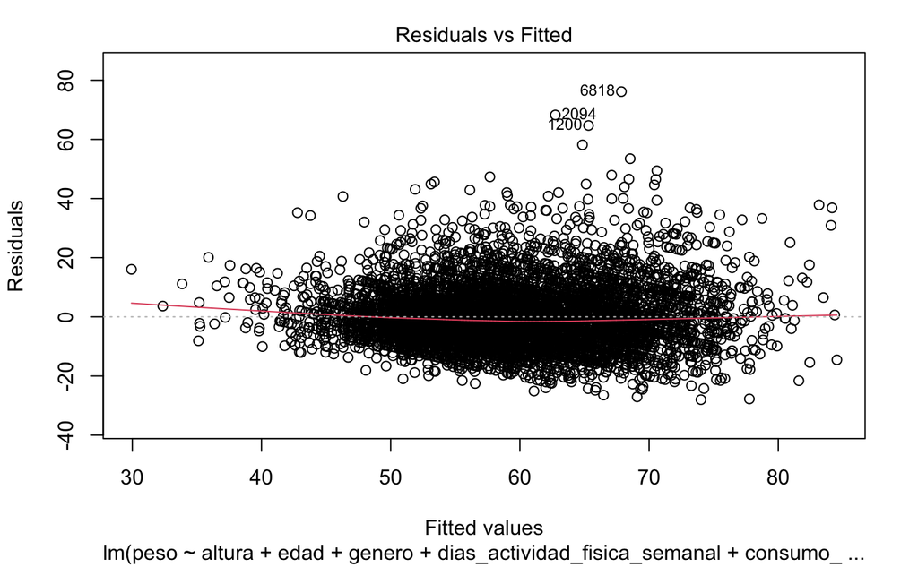

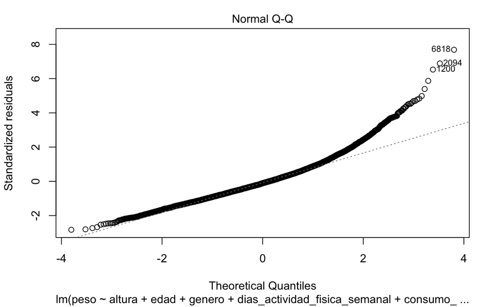

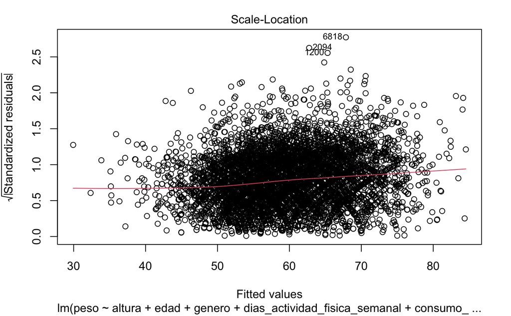

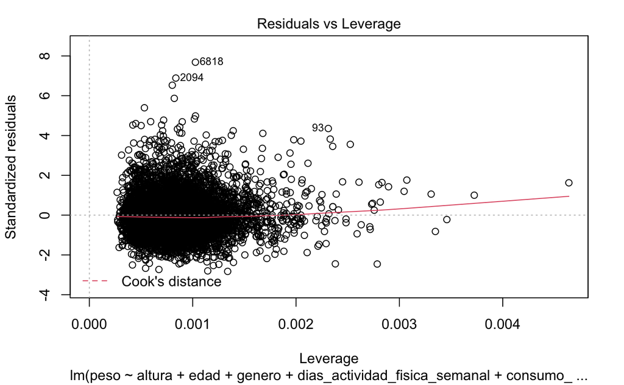

```r
plot(modelo_peso)
```

## En el gráfico de residuos vs valores predichos se puede apreciar una leve curvatura.

## En el gráfico normal qqplot podemos ver que el extremo superior no se ajust a la distribución teórica.

# Modelo Robusto

```r
df_outliers = read.csv('encuesta_salud_modelo6.csv')
```

```r
modelo_peso_5 = lm(formula=peso ~ altura + edad + genero + dias_actividad_fisica_semanal + consumo_diario_alcohol,
                   data = df_outliers)

tidy_modelo_peso_5 = tidy(modelo_peso_5, conf.int=TRUE)

tidy_modelo_peso_5
```

| term | estimate | std.error | statistic | p.value | conf.low | conf.high |
| --- | --- | --- | --- | --- | --- | --- |
| (Intercept) | -70.03018295 | 2.83276287 | -24.7215126 | 1.790765e-129 | -75.5832490 | -64.47711693 |
| altura | 0.66195138 | 0.01742572 | 37.9870250 | 1.870181e-287 | 0.6277917 | 0.69611103 |
| edad | 1.40007823 | 0.11365594 | 12.3185668 | 1.626058e-34 | 1.1772785 | 1.62287800 |
| generoMasculino | 1.03107761 | 0.33064054 | 3.1184246 | 1.825528e-03 | 0.3829228 | 1.67923239 |
| dias_actividad_fisica_semanal | -0.11320339 | 0.06040012 | -1.8742245 | 6.094078e-02 | -0.2316058 | 0.00519899 |
| consumo_diario_alcohol | 0.02083144 | 0.07436556 | 0.2801221 | 7.793920e-01 | -0.1249474 | 0.16661027 |

```r
summary(modelo_peso_5)
```

```
Call:
lm(formula = peso ~ altura + edad + genero + dias_actividad_fisica_semanal +
    consumo_diario_alcohol, data = df_outliers)

Residuals:
    Min      1Q  Median      3Q     Max
-28.615  -6.964  -1.510   4.692 113.483

Coefficients:
                               Estimate Std. Error t value Pr(>|t|)
(Intercept)                   -70.03018    2.83276 -24.722  < 2e-16 ***
altura                          0.66195    0.01743  37.987  < 2e-16 ***
edad                            1.40008    0.11366  12.319  < 2e-16 ***
generoMasculino                 1.03108    0.33064   3.118  0.00183 **
dias_actividad_fisica_semanal  -0.11320    0.06040  -1.874  0.06094 .
consumo_diario_alcohol          0.02083    0.07437   0.280  0.77939
---
Signif. codes:  0 ‘***’ 0.001 ‘**’ 0.01 ‘*’ 0.05 ‘.’ 0.1 ‘ ’ 1

Residual standard error: 12.04 on 7054 degrees of freedom
Multiple R-squared:  0.2737,    Adjusted R-squared:  0.2732
F-statistic: 531.8 on 5 and 7054 DF,  p-value: < 2.2e-16
```

```r
pred_modelo_5 = augment(modelo_peso_5, newdata = df_test)
#pred_modelo_5 %>% select( .fitted, .resid)
```

```r
rmse(data=pred_modelo_5, truth = peso, estimate=.fitted)
```

| .metric | .estimator | .estimate |
| --- | --- | --- |
| rmse | standard | 10.22824 |

```r
mae(data=pred_modelo_5, truth= peso, estimate=.fitted)
```

| .metric | .estimator | .estimate |
| --- | --- | --- |
| mae | standard | 7.657067 |

```r
modelo_peso_6 = lmrob(formula=peso ~ altura + edad + genero + dias_actividad_fisica_semanal + consumo_diario_alcohol,
                      data = df_outliers)
```

```r
summary(modelo_peso_6)
```

```
Call:
lmrob(formula = peso ~ altura + edad + genero + dias_actividad_fisica_semanal +
    consumo_diario_alcohol, data = df_outliers)
 \--> method = "MM"
Residuals:
     Min       1Q   Median       3Q      Max
-25.9082  -5.6143  -0.1514   6.0878 115.4825

Coefficients:
                               Estimate Std. Error t value  Pr(>|t|)
(Intercept)                   -63.71242    2.25261 -28.284   < 2e-16 ***
altura                          0.62359    0.01449  43.041   < 2e-16 ***
edad                            1.27269    0.08694  14.638   < 2e-16 ***
generoMasculino                 1.11503    0.25240   4.418 0.0000101 ***
dias_actividad_fisica_semanal  -0.00211    0.04592  -0.046     0.963
consumo_diario_alcohol          0.07219    0.05579   1.294     0.196
---
Signif. codes:  0 ‘***’ 0.001 ‘**’ 0.01 ‘*’ 0.05 ‘.’ 0.1 ‘ ’ 1

Robust residual standard error: 8.579
Multiple R-squared:  0.3869,    Adjusted R-squared:  0.3865
Convergence in 12 IRWLS iterations

Robustness weights:
 62 observations c(93,248,779,1200,1389,1657,1702,2094,2232,2637,2882,2998,3002,3656,4084,4105,4631,5043,5174,5813,6114,6251,6369,6683,6818,6956,7025,7026,7027,7028,7029,7030,7031,7032,7033,7034,7035,7036,7037,7038,7039,7040,7041,7042,7043,7044,7045,7046,7047,7048,7049,7050,7051,7052,7053,7054,7055,…
     are outliers with |weight| = 0 ( < 1.4e-05);
 572 weights are ~= 1. The remaining 6426 ones are summarized as
     Min.   1st Qu.    Median      Mean   3rd Qu.      Max.
0.0000908 0.8667000 0.9513000 0.8928000 0.9858000 0.9990000
Algorithmic parameters:
       tuning.chi                bb        tuning.psi        refine.tol           rel.tol         scale.tol         solve.tol       eps.outlier
        1.548e+00         5.000e-01         4.685e+00         1.000e-07         1.000e-07         1.000e-10         1.000e-07         1.416e-05
            eps.x warn.limit.reject warn.limit.meanrw
        3.638e-10         5.000e-01         5.000e-01
     nResample         max.it       best.r.s       k.fast.s          k.max    maxit.scale      trace.lev            mts     compute.rd fast.s.large.n
           500             50              2              1            200            200              0           1000              0           2000
                  psi           subsampling                   cov compute.outlier.stats
           "bisquare"         "nonsingular"         ".vcov.avar1"                  "SM"
seed : int(0)
```

Se puede ver un descenso en el $R^{2}$ del modelo inicial con el set de datos de entrenamiento que contiene valores outliers.

```r
pred_modelo_6 = augment(modelo_peso_6, newdata = df_test)
```

```r
rmse(data=pred_modelo_6, truth = peso, estimate=.fitted)
```

| .metric | .estimator | .estimate |
| --- | --- | --- |
| rmse | standard | 10.29556 |

```r
mae(data=pred_modelo_6, truth= peso, estimate=.fitted)
```

| .metric | .estimator | .estimate |
| --- | --- | --- |
| mae | standard | 7.514827 |

Sin embargo, no se notan diferencias en las métricas de error $RMSE$ y $MAE$ en el set de datos de testeo.